# Developing a purchasing impacts app based on USEEIO impact intensities

by Martin Brown

### Introduction

In this R Markdown workbook I’m going to develop a Shiny app that takes spending data, expressed in BEA/NAICS categories, and converts those data to estimated supply chain (Scope 3) environmental impacts, based on impact intensities found in the USEEIO model.

For the time being the only impact category reported on will be greenhouse gas emissions, because the EPA has recently published a [convenient set of impact intensities for greenhouse gases](https://cfpub.epa.gov/si/si_public_record_Report.cfm?dirEntryId=349324&Lab=CESER). But I will try to structure it so that if other impact categories become doable in the future, they can be added easily.

### Tracks of work

To make the app, I’ll have to combine several sets of data and tracks of work.

To output estimated supply chain emissions, based on dollars expended, I need to combine:

- emissions intensity data, from the EPA’s publications. This is easy to download but needs to be filtered and reformed before it’s used in the app.
- global warming potential data. I definitely want to give some options here.
- spending data, from Oregon or any other source, but in categories compatible with the EPA’s emissions intensities

But to make that happen in the app,

- the emissions intensity data needs to be in a filtered tidy data frame
- the spending data has to be uploaded and checked for compatibility (inside the app)
- a number of global warming potential profiles have to be available

### Set up

```r
# load packages I like to use
library(checkpoint)
library(tidyverse)
library(readxl)
library(kableExtra)
library(ggthemes)
library(viridis)
# use packages as of a certain reference date
checkpoint(snapshot_date = "2021-06-15")
```

```
Using checkpoint directory E:/.checkpoint/2021-06-15/lib/i386-w64-mingw32/4.1.0
```

```r
# define some graphic conventions
# graphic conventions
# create a custom theme for ggplots (assumes ggthemes is loaded)
theme_539 <- function() {
  theme_fivethirtyeight() +
    theme(
      rect=element_rect(fill="transparent"),
      panel.grid.major = element_blank(),
      axis.ticks = element_line(),
      plot.title.position = "plot",
      plot.title = element_text(hjust=0)
    )
}


# see what my working directory is
getwd()
```

```
[1] "C:/Users/mbrown2/Documents/Local repositories/purchasingImpacts"
```

### Emissions intensities

I’ve downloaded the EPA’s ghg emissions intensities from the web. I need to choose the sheet(s) most relevant to me, download the data, and tidy it. Maybe along the way I’ll print out some of the documentation sheets.

```r
# set EPA ghg filespec
epaGHGdataFileSpec <-
  "source_data/SupplyChainEmissionFactorsforUSIndustriesCommodities.xlsx"
# find out what sheets are there
epaGHGdataAvailableSheets <-
  excel_sheets(path=epaGHGdataFileSpec)
kable(
  as.data.frame(epaGHGdataAvailableSheets),
  caption="available sheets"
)
```

available sheets

| epaGHGdataAvailableSheets |
| --- |
| Cover |
| Contents |
| Data Dictionary |
| Sources |
| LCIA Factors of Other GHGs |
| 2016_Summary_Commodity |
| 2015_Summary_Commodity |
| 2014_Summary_Commodity |
| 2013_Summary_Commodity |
| 2012_Summary_Commodity |
| 2011_Summary_Commodity |
| 2010_Summary_Commodity |
| 2016_Summary_Industry |
| 2015_Summary_Industry |
| 2014_Summary_Industry |
| 2013_Summary_Industry |
| 2012_Summary_Industry |
| 2011_Summary_Industry |
| 2010_Summary_Industry |
| 2016_Detail_Commodity |
| 2015_Detail_Commodity |
| 2014_Detail_Commodity |
| 2013_Detail_Commodity |
| 2012_Detail_Commodity |
| 2011_Detail_Commodity |
| 2010_Detail_Commodity |
| 2016_Detail_Industry |
| 2015_Detail_Industry |
| 2014_Detail_Industry |
| 2013_Detail_Industry |
| 2012_Detail_Industry |
| 2011_Detail_Industry |
| 2010_Detail_Industry |

Since my goal is to find the supply chain emissions of purchases, it seems right to use the Commodity based tables. Which of the many commodity options should I choose?

The year records are a bit confusing, but I think they refer to versions of the I/O tables. All of the emissions intensities are in kg per 2018 dollars. TO DO: FIND OUT WHAT THE DIFFERENT YEARS REPRESENT.

But: assuming I want the most recent, what I should import is:

- 2016_Summary_Commodity
- 2016_Detail_Commodity

```r
# import my sheets of interest
epaGHGdataSet1raw <-
  read_excel(
    path=epaGHGdataFileSpec,
    sheet="2016_Summary_Commodity"
  )
```

```
* `` -> ...8
```

```r
epaGHGdataSet2raw <-
  read_excel(
    path=epaGHGdataFileSpec,
    sheet="2016_Detail_Commodity"
  )
```

```
* `` -> ...8
```

Looks like there is a data dictionary I might want to print out for the record. These are the field names in the Excel tables.

```r
epaGHGdataDictionary <-
  read_excel(path=epaGHGdataFileSpec, sheet="Data Dictionary")
kable(epaGHGdataDictionary) %>%
  kable_styling(bootstrap_options = "bordered")
```

| Field Name | Definition |
| --- | --- |
| Commodity Code | Code of the commodity or industry from the BEA Make and Use Tables 2012 categorization. 'Detail' and 'summary' are two levels of detail BEA publishes economic input-output accounts data at. 'Detail' l… |
| Commodity Name | Name of the commodity or industry from the BEA Make and Use Tables 2012 categorization, except detail commodities, which use USEEIO v1.1 names, see Ingwersen and Yang 2017) |
| Substance | Greenhouse gas: 'carbon dioxide' is CO2; 'methane' is CH4; 'nitrous oxide' is N2O; and 'other GHGs' include HFC-23, HFC-32, HFC-125, HFC-134a, HFC-143a, HFC-236fa, CF4, C2F6, C3F8, C4F8, SF6, and NF3 |
| Unit | Unit of emission factors for each gas. 'Other GHGs' are aggregated and reported in CO2e (carbon dioxide equivalents) using the IPCC AR4 100-year GWP factors. Purchaser price is the price paid by the c… |
| Supply Chain Emission Factors without Margins | Direct and indirect GHG emissions associated with production of commodity or industry from cradle to the point of production(kg) per 2018 USD of that commodity or industry in the US in purchaser price… |
| Margins of Supply Chain Emission Factors | Direct and indirect GHG emissions associated with production of commodity or industry from the point of production to the point of sale (kg) per 2018 USD of that commodity or industry in the US in pur… |
| Supply Chain Emission Factors with Margins | Direct and indirect GHG emissions associated with production of commodity or industry from cradle to the point of sale(kg) per 2018 USD of that commodity or industry in purchaser price of that commodi… |
| DQ ReliabilityScore of Factors without Margins | Data reliability scores for model results using USEPA 2016 Data quality assessment system, where 1 is the better quality and 5 the poorer quality |
| DQ TemporalCorrelation of Factors without Margins | Data technological correlation scores for model results using USEPA 2016 Data quality assessment system, where 1 is the better quality and 5 the poorer quality |
| DQ GeographicalCorrelation of Factors without Margins | Data collection scores for model results using USEPA 2016 Data quality assessment system, where 1 is the better quality and 5 the poorer quality |
| DQ TechnologicalCorrelation of Factors without Margins | Data geographical correlatoin scores for model results using USEPA 2016 Data quality assessment system, where 1 is the better quality and 5 the poorer quality |
| DQ DataCollection of Factors without Margins | Data temporal correlation scores for model results using USEPA 2016 Data quality assessment system, where 1 is the better quality and 5 the poorer quality |

I’m not going to need all those fields. Let’s select and rename fields.

```r
# select desired fields and rename them for brevity
epaGHGdataSet1 <-
  epaGHGdataSet1raw %>%
  select(
    `Commodity Code`,
    `Commodity Name`,
    `Substance`,
    `Unit`,
    `Supply Chain Emission Factors without Margins`
  ) %>%
  rename(
    beaCode=`Commodity Code`,
    beaName=`Commodity Name`,
    substance=Substance,
    unit=Unit,
    impFactor=`Supply Chain Emission Factors without Margins`
  )
epaGHGdataSet2 <-
  epaGHGdataSet2raw %>%
  select(
    `Commodity Code`,
    `Commodity Name`,
    `Substance`,
    `Unit`,
    `Supply Chain Emission Factors without Margins`
  ) %>%
  rename(
    beaCode=`Commodity Code`,
    beaName=`Commodity Name`,
    substance=Substance,
    unit=Unit,
    impFactor=`Supply Chain Emission Factors without Margins`
  )
```

Now I know I would like to combine these two tables – so that users can enter expenditures in either detail or summary levels of detail (and mix and match). That will be most convenient if the beaCodes and beaNames do not overlap between the two tables. Let’s check.

```r
epaGHGbeaCodes1 <-
  epaGHGdataSet1 %>% select(beaCode) %>% distinct()
epaGHGbeaCodes2 <-
  epaGHGdataSet2 %>% select(beaCode) %>% distinct()
inner_join(
  epaGHGbeaCodes2 ,
  epaGHGbeaCodes1 ,
  by="beaCode"
) %>% print()
```

| beaCode |
| --- |

whew, it looks like none overlap. Let’s try the commodity names.

```r
epaGHGbeaNames1 <-
  epaGHGdataSet1 %>% select(beaName) %>% distinct()
epaGHGbeaNames2 <-
  epaGHGdataSet2 %>% select(beaName) %>% distinct()
inner_join(
  epaGHGbeaNames2 %>% mutate(level="detail"),
  epaGHGbeaNames1 %>% mutate(level="summary"),
  by="beaName"
) %>% print()
```

| beaName | level.x | level.y |
| --- | --- | --- |
| Other transportation equipment | detail | summary |
| Food and beverage stores | detail | summary |
| General merchandise stores | detail | summary |
| Other real estate | detail | summary |
| Legal services | detail | summary |
| Hospitals | detail | summary |

Looks like there is a little overlap in the names. But not in the codes. So if I use codes as the key variable then it won’t matter.  
I could also visually indicate the summary level textually – all caps maybe?

Let’s try combining the names and printing them out as a table.

```r
# make a combined epa commodity table
epaAllCommodityTable <-
  bind_rows(
    epaGHGdataSet1 %>%
      select(beaCode, beaName) %>%
      mutate(
        dtlLvl="summary",
        beaName=str_to_upper(beaName)
      ) %>%
      distinct(),
    epaGHGdataSet2 %>%
      select(beaCode, beaName) %>%
      mutate(dtlLvl="detail") %>%
      distinct()
  ) %>%
  arrange(beaCode, beaName)
kable(epaAllCommodityTable) %>%
  kable_styling(bootstrap_options = "responsive")
```

| beaCode | beaName | dtlLvl |
| --- | --- | --- |
| 1111A0 | Fresh soybeans, canola, flaxseeds, and other oilseeds | detail |
| 1111B0 | Fresh wheat, corn, rice, and other grains | detail |
| 111200 | Fresh vegetables, melons, and potatoes | detail |
| 111300 | Fresh fruits and tree nuts | detail |
| 111400 | Greenhouse crops, mushrooms, nurseries, and flowers | detail |
| 111900 | Tobacco, cotton, sugarcane, peanuts, sugar beets, herbs and spices, and other crops | detail |
| 111CA | FARMS | summary |
| 112120 | Dairies | detail |
| 1121A0 | Cattle ranches and feedlots | detail |
| 112300 | Poultry farms | detail |
| 112A00 | Animal farms and aquaculture ponds (except cattle and poultry) | detail |
| 113000 | Timber and raw forest products | detail |
| 113FF | FORESTRY, FISHING, AND RELATED ACTIVITIES | summary |
| 114000 | Wild-caught fish and game | detail |
| 115000 | Agriculture and forestry support | detail |
| 211 | OIL AND GAS EXTRACTION | summary |
| 211000 | Unrefined oil and gas | detail |
| 212 | MINING, EXCEPT OIL AND GAS | summary |
| 212100 | Coal | detail |
| 212230 | Copper, nickel, lead, and zinc | detail |
| 2122A0 | Iron, gold, silver, and other metal ores | detail |
| 212310 | Dimensional stone | detail |
| 2123A0 | Sand, gravel, clay, phosphate, other nonmetallic minerals | detail |
| 213 | SUPPORT ACTIVITIES FOR MINING | summary |
| 213111 | Well drilling | detail |
| 21311A | Other support activities for mining | detail |
| 22 | UTILITIES | summary |
| 221100 | Electricity | detail |
| 221200 | Natural gas | detail |
| 221300 | Drinking water and wastewater treatment | detail |

[output cut: 430 more lines]

Well, what this tells me is that I can definitely add the two tables together. But I need to preserve the beaCode and (probably for clarity) also preserve the dtlLvl and also mark off the summary level somehow (as with all caps).

All right let’s make it.

```r
# make the combined impact intensities table
epaGHGimpactIntensities <-
  bind_rows(
    epaGHGdataSet1 %>%
      mutate(
        dtlLvl="summary",
        beaName=str_to_upper(beaName)
      ),
    epaGHGdataSet2 %>%
      mutate(
        dtlLvl="detail"
      )
  ) %>%
  arrange(beaCode, beaName, substance)
```

So object epaGHGimpactIntensities is what I’ll use.

```r
# clean up workspace by deleting most objects
rm(
  list=
    setdiff(
      ls(),
      c("epaGHGimpactIntensities", "epaGHGdataDictionary",
        "theme_539")
  )
)
```

### importing the spending data.

In the app I need to import a user’s file and then check that their data meets the acceptable categories.

So let’s develop the acceptable list first.

```r
# make acceptable spending category data frame & save it as disk file
okSpendingCats <-
  epaGHGimpactIntensities %>%
  select(beaCode, beaName, dtlLvl) %>%
  distinct() %>%
  arrange(beaCode, beaName)
saveRDS(okSpendingCats, "intermediate_data/okSpendingCats.RData")
```

Now, in a somewhat non-reproducible step, I’m going to create an Excel template to allow people to enter spending data in an acceptable format. It is available in the “source_data” folder as “users_spending_data_blank.xlsx”. This may be copied and altered by users and uploaded to the app.

Now I’ve got to take some spending data and see how it matches up. More generally, I’ve got to figure out how to “validate” the incoming data…

- is it in the right format? (e.g. codes as text, spending as integer)
- do all the codes have entries in the okSpendingCats?

Let’s try it with two different data files.

- Rivin’s Oregon spending data file produced in 2020 (from an obsolete version of this analysis)
- A fictional spending data file using the template produced above.

```r
# get Rivin's draft spending file, circa 2020
exampleSpendingData1 <-
  read_excel(
    path="../quick-purchasing-impacts/source_data/oregon_spending_2020_04_23.xlsx",
    sheet="martin5",
    skip=4,
    col_names = TRUE,
    col_types = c("text", "text", "text", "numeric")
  ) %>%
  rename(
    userCategory=`DEQ Category`,
    beaCode=`BAE  Code`,
    userSpending=`BEA cost`
  ) %>%
  select(beaCode, userSpending, userCategory) %>%
  filter(userSpending > 0) %>%
  mutate(
    # a manual edit based on a typo discovered below
    beaCode=ifelse(beaCode=="GSLGH", "5412OP", beaCode)
  ) %>%
  arrange(beaCode, desc(userSpending))

# print out rows of spending data
print(nrow(exampleSpendingData1))
```

```
[1] 354
```

```r
# count how many rows join based on beaCode
semi_join(
  exampleSpendingData1,
  okSpendingCats,
  by="beaCode"
) %>% nrow() %>% print()
```

```
[1] 354
```

```r
# print out rows that don't match
anti_join(
  exampleSpendingData1,
  okSpendingCats,
  by="beaCode"
) %>%
kable() %>% kable_styling(bootstrap_options = "responsive")
```

| beaCode | userSpending | userCategory |
| --- | --- | --- |

Good news – nearly everything matched up. The examination above uncovered just one mismatch, which I found a reasonable substitute for.

Ok, let’s try the template I created.

```r
# import spreadsheet with spending data
exampleSpendingData2 <-
  read_excel(
    path="source_data/users_spending_data_sample.xlsx",
    skip=11,
    col_names = TRUE
  ) %>%
  select(beaCode, userSpending, userCategory) %>%
  filter(userSpending > 0) %>%
  mutate(
    # use this space for manual edits
  ) %>%
  arrange(beaCode, desc(userSpending))

# print out rows of spending data
print(nrow(exampleSpendingData2))
```

```
[1] 17
```

```r
# count how many rows join based on beaCode
semi_join(
  exampleSpendingData2,
  okSpendingCats,
  by="beaCode"
) %>% nrow() %>% print()
```

```
[1] 17
```

```r
# print out rows that don't match
anti_join(
  exampleSpendingData2,
  okSpendingCats,
  by="beaCode"
) %>%
kable() %>% kable_styling(bootstrap_options = "responsive")
```

| beaCode | userSpending | userCategory |
| --- | --- | --- |

Looks like that’s the way to do it.

- load in the table
- reduce to those 3 standard fields
- check for semi_joins and anti_joins
- print out any anti_joins

At this moment I’m going to create the file for the shiny app to see if I can upload data in the form of the template.

…

Looks like I got that working. I’m going to have to add a lot of features later, like

- additional validation
- an example file to download
- choice of using preset data from ORegon

but that can go later.

```r
# saving example datasets into the app directory
saveRDS(exampleSpendingData2, "shinyApp/householdSpending.RData")
saveRDS(exampleSpendingData1, "shinyApp/governmentProcurement.RData")
```

### global warming potentials

The EPA data gives masses per expended $ for 3 particular gasses, and CO2 equivalents for one umbrella category “other gasses”. This gives the option of choosing your own Global Warming potentials (e.g. IPCC AR4 20 year, etc.), but dealing with those other gases will be a pain.

- CO2 masses will always have a GWP of 1 (from defintion of GWP).
- CH4 masses will have a varying GWP I can get from tables of GWP’s.
- N2O masses will have a varying GWP I can get from tables of GWP’s.
- the other gases are already reported with an inherent GWP (from AR4 100 year). If I want to correct this I need to figure out the relationship of “other gas” GWP’s under AR4 100 to their GWP’s under other views.

Let’s read in some GWP’s and do some filtering.

```r
# filespec of spreadsheet with GWP's from GaBi
GWPfilespec <- "source_data/gwp_factors_from_gabi.xlsx"

# get list of sheets in source file
listOfGWPsheets <-
  excel_sheets(path=GWPfilespec)

# read each sheet and label the estimates from sheet name
for (i in 1:length(listOfGWPsheets)) {
  tempDF <-
    read_excel(
      path=GWPfilespec,
      sheet=listOfGWPsheets[i],
      skip=22,
      col_names=c("compound", "junk1", "junk2", "gwp", "includeMe"),
      col_types=c("text", "numeric", "text", "numeric", "numeric")
    ) %>%
    filter(gwp>0 & includeMe>0) %>%
    select(compound, gwp) %>%
    mutate(
      gwpVersion=listOfGWPsheets[i],
      substance=
        case_when(
          compound=="Carbon dioxide [Inorganic emissions to air]" ~
            "carbon dioxide",
          compound=="Methane (biotic) [Organic emissions to air (group VOC)]" ~ "methane",
          compound=="Nitrous oxide (laughing gas) [Inorganic emissions to air]" ~ "nitrous oxide",
          TRUE ~ "other GHGs"
        )
    )

  if (i==1) {
    gwpCollection <- tempDF[0,]
  }

  gwpCollection <-
    bind_rows(gwpCollection, tempDF)
}

# now lets summarize that GWP collection by gas group.
GWPtoUseAlmost <-
  gwpCollection %>%
  mutate(log10gwp=log10(gwp)) %>%
  group_by(gwpVersion, substance) %>%
  summarise(log10gwp=mean(log10gwp)) %>%
  ungroup() %>%
  mutate(gwp=10**log10gwp) %>%
  select(-log10gwp)
# for the "other GHGs" I can't use those values as calculated.
# I have to use a standard... for now let's say AR5 100.
# when I get the data I should update that to AR4 100.
standardValueForOtherGases <-
  GWPtoUseAlmost %>%
  filter(gwpVersion=="IPCC AR4 100", substance=="other GHGs") %>%
  pull(gwp)

GWPtoUse <-
  GWPtoUseAlmost %>%
  mutate(
    gwp=ifelse(
      substance=="other GHGs", gwp/standardValueForOtherGases, gwp
    )
  )

kable(GWPtoUse)
```

| gwpVersion | substance | gwp |
| --- | --- | --- |
| IPCC AR4 100 | carbon dioxide | 1.000000 |
| IPCC AR4 100 | methane | 25.000000 |
| IPCC AR4 100 | nitrous oxide | 298.000000 |
| IPCC AR4 100 | other GHGs | 1.000000 |
| IPCC AR4 20 | carbon dioxide | 1.000000 |
| IPCC AR4 20 | methane | 72.000000 |
| IPCC AR4 20 | nitrous oxide | 289.000000 |
| IPCC AR4 20 | other GHGs | 2.350277 |
| IPCC AR5 100 | carbon dioxide | 1.000000 |
| IPCC AR5 100 | methane | 28.000000 |
| IPCC AR5 100 | nitrous oxide | 265.000000 |
| IPCC AR5 100 | other GHGs | 0.990927 |
| IPCC AR5 20 | carbon dioxide | 1.000000 |
| IPCC AR5 20 | methane | 84.000000 |
| IPCC AR5 20 | nitrous oxide | 264.000000 |
| IPCC AR5 20 | other GHGs | 2.390124 |

So looking at that table, all the figures for major gasses are correct. For the “other gases” its supposed to be a ratio vs. the value for AR4 100. The AR4 20 value makes sense. Not sure about the AR5 values – because unfortunately they did not come from completely compatible data sets. I will have to see how much the other gases contribute to the results.

If they contribute a lot, I may need to go back into that table and try to make the AR5 selections more compatible with AR4. Looks like there are more gases in the AR5, so I would try to use the AR4 subset, maybe with a flag field?

Let’s save that table to the intermediate zone so it can be used in the app.

```r
saveRDS(GWPtoUse, file="intermediate_data/GWPtoUse.RData")
```

### Putting it together in a sample calculation

so now I’ve got some example spending, e.g.

```r
kable(head(exampleSpendingData2))
```

| beaCode | userSpending | userCategory |
| --- | --- | --- |
| 221100 | 100 | Utilities |
| 221200 | 73 | Utilities |
| 221300 | 160 | Utilities |
| 336991 | 100 | Transportation |
| 445000 | 1000 | Food & dining |
| 485000 | 200 | Transportation |

and some emissions intensity data, e.g.

```r
kable(head(epaGHGimpactIntensities))
```

| beaCode | beaName | substance | unit | impFactor | dtlLvl |
| --- | --- | --- | --- | --- | --- |
| 1111A0 | Fresh soybeans, canola, flaxseeds, and other oilseeds | carbon dioxide | kg/2018 USD, purchaser price | 0.323 | detail |
| 1111A0 | Fresh soybeans, canola, flaxseeds, and other oilseeds | methane | kg/2018 USD, purchaser price | 0.001 | detail |
| 1111A0 | Fresh soybeans, canola, flaxseeds, and other oilseeds | nitrous oxide | kg/2018 USD, purchaser price | 0.002 | detail |
| 1111A0 | Fresh soybeans, canola, flaxseeds, and other oilseeds | other GHGs | kg CO2e/2018 USD, purchaser price | 0.003 | detail |
| 1111B0 | Fresh wheat, corn, rice, and other grains | carbon dioxide | kg/2018 USD, purchaser price | 0.658 | detail |
| 1111B0 | Fresh wheat, corn, rice, and other grains | methane | kg/2018 USD, purchaser price | 0.006 | detail |

and some GWP data, eg.

```r
kable(head(GWPtoUse))
```

| gwpVersion | substance | gwp |
| --- | --- | --- |
| IPCC AR4 100 | carbon dioxide | 1 |
| IPCC AR4 100 | methane | 25 |
| IPCC AR4 100 | nitrous oxide | 298 |
| IPCC AR4 100 | other GHGs | 1 |
| IPCC AR4 20 | carbon dioxide | 1 |
| IPCC AR4 20 | methane | 72 |

and all I need to do is put them together in a way that can be filtered.

so, impact=spending x intensity x gwp. now that I think about it, the intensity and gwp tables will never change, so I can just merge them.

```r
# combine the intensity and GWP tables
impactIntensitiesWithGWPversions <-
  full_join(
    epaGHGimpactIntensities %>%
      mutate(
        impactCategory="GHG emissions",
        impactUnits="kg CO2e"
    ),
    GWPtoUse,
    by="substance"
  )
# save the result as a disk file
saveRDS(
  impactIntensitiesWithGWPversions,
  "intermediate_data/impactIntensitiesWithGWPversions.RData"
)
write.csv(
  impactIntensitiesWithGWPversions,
  "intermediate_data/impactIntensitiesWithGWPversions.csv",
  row.names=F
)
saveRDS(
  impactIntensitiesWithGWPversions,
  "shinyApp/impactIntensitiesWithGWPversions.RData"
)
```

now let’s merge with some spending data and filter. this is the kind of merge that will need to be made in the app. users will select gwp version and (eventually) impact category

```r
#
testDF <-
  left_join(
    exampleSpendingData2,
    impactIntensitiesWithGWPversions,
    by="beaCode"
  ) %>%
  filter(
    impactCategory=="GHG emissions" &
    gwpVersion %in% "IPCC AR4 100"
  ) %>%
  mutate(
    impact=userSpending*impFactor*gwp,
    actualSpending=ifelse(substance=="carbon dioxide", userSpending, 0)
  )
```

now let’s sum impacts by beaName and by userCategory

```r
testDF2 <-
  testDF %>%
  group_by(impactCategory, impactUnits, beaName) %>%
  summarise(
    userSpending=sum(actualSpending),
    impact=sum(impact)
  )
kable(testDF2)
```

| impactCategory | impactUnits | beaName | userSpending | impact |
| --- | --- | --- | --- | --- |
| GHG emissions | kg CO2e | Cable and subscription programming | 30 | 3.270 |
| GHG emissions | kg CO2e | Drinking water and wastewater treatment | 160 | 98.880 |
| GHG emissions | kg CO2e | Electricity | 100 | 374.900 |
| GHG emissions | kg CO2e | Elementary and secondary schools | 500 | 81.000 |
| GHG emissions | kg CO2e | Food and beverage stores | 1000 | 286.000 |
| GHG emissions | kg CO2e | FOOD SERVICES AND DRINKING PLACES | 500 | 112.500 |
| GHG emissions | kg CO2e | Hospitals | 500 | 86.000 |
| GHG emissions | kg CO2e | Motorcycle, bicycle, and parts | 100 | 8.300 |
| GHG emissions | kg CO2e | Natural gas | 73 | 58.400 |
| GHG emissions | kg CO2e | Other educational services | 300 | 44.700 |
| GHG emissions | kg CO2e | OTHER SERVICES, EXCEPT GOVERNMENT | 311 | 47.583 |
| GHG emissions | kg CO2e | Outpatient healthcare | 1000 | 142.000 |
| GHG emissions | kg CO2e | Passenger ground transport | 200 | 80.600 |
| GHG emissions | kg CO2e | Radio and television | 16 | 1.120 |
| GHG emissions | kg CO2e | Salons and barber shops | 50 | 7.400 |
| GHG emissions | kg CO2e | Telecommunications | 80 | 6.560 |
| GHG emissions | kg CO2e | Wireless telecommunications | 80 | 8.880 |

and

```r
testDF3 <-
  testDF %>%
  group_by(impactCategory, impactUnits, userCategory) %>%
  summarise(
    userSpending=sum(actualSpending),
    impact=sum(impact)
  )
kable(testDF3)
```

| impactCategory | impactUnits | userCategory | userSpending | impact |
| --- | --- | --- | --- | --- |
| GHG emissions | kg CO2e | Education | 800 | 125.700 |
| GHG emissions | kg CO2e | Entertainment | 46 | 4.390 |
| GHG emissions | kg CO2e | Food & dining | 1500 | 398.500 |
| GHG emissions | kg CO2e | Grooming | 50 | 7.400 |
| GHG emissions | kg CO2e | Health care | 1500 | 228.000 |
| GHG emissions | kg CO2e | Services | 311 | 47.583 |
| GHG emissions | kg CO2e | Transportation | 300 | 88.900 |
| GHG emissions | kg CO2e | Utilities | 493 | 547.620 |

ok, i have previewed the processing!

let’s clean up the workspace

```r
# clean up workspace by deleting most objects
rm(
  list=
    setdiff(
      ls(),
      c("epaGHGimpactIntensities", "epaGHGdataDictionary",
        "impactIntensitiesWithGWPversions", "okSpendingCats",
        "exampleSpendingData1", "exampleSpendingData2",
        "theme_539")
  )
)
```

### Drafting illustrations for app

Let’s imagine we’re making spending and impact charts for the app, and want it to be as flexible/reactive as possible.

So first step is we combine the spending and impact frames in full detail… no filtering

```r
# making the basic merge.
# later this will be reactive, because the imported spending
# data file could change
impactsInDetail <-
  left_join(
    exampleSpendingData2,
    impactIntensitiesWithGWPversions,
    by="beaCode"
  ) %>%
  mutate(
    impact=userSpending*impFactor*gwp,
    actualSpending=ifelse(substance=="carbon dioxide", userSpending, 0)
  )

# making some lists of spending categories by abundance.
# later these will be reactive too because they will change based on
# the input data file
userCategoryNames <-
  impactsInDetail %>%
  group_by(userCategory) %>%
  summarise(actualSpending=sum(actualSpending)) %>%
  ungroup() %>%
  arrange(desc(actualSpending)) %>%
  pull(userCategory)
beaCategoryNames <-
  impactsInDetail %>%
  group_by(beaCode, beaName) %>%
  summarise(actualSpending=sum(actualSpending)) %>%
  ungroup() %>%
  arrange(desc(actualSpending)) %>%
  pull(beaName)
gwpVersionNames <-
  impactsInDetail %>%
  group_by(gwpVersion) %>%
  summarise(
    impact=sum(ifelse(impactCategory=="GHG emissions", impact, 0))
  ) %>%
  ungroup() %>%
  arrange(desc(impact)) %>%
  pull(gwpVersion)
```

now to make a display i filter that and summarise it by the desired level of detail, in this case the user spending category.

```r
# a data frame that's later going to be reactive
userCategoryChartData <-
  impactsInDetail %>%
  filter(
    # later to be a selection in app...
    impactCategory=="GHG emissions",
    # later to be a multi checkbox selection in app...
    gwpVersion %in% c("IPCC AR5 100", "IPCC AR5 20")
  ) %>%
  group_by(impactCategory, impactUnits, gwpVersion, userCategory) %>%
  summarise(
    impact=sum(impact),
    actualSpending=sum(actualSpending)
  ) %>%
  ungroup() %>%
  mutate(
    userCategory=factor(userCategory, levels=rev(userCategoryNames)),
    gwpVersion=factor(gwpVersion, levels=rev(gwpVersionNames))
  )
# a title for the impact category.. to be reactive
userCategoryImpactChartTitle <-
  paste(
    userCategoryChartData %>%
      select(impactCategory) %>%
      pull(impactCategory) %>%
      unique(),
    " (",
    userCategoryChartData %>%
      select(impactUnits) %>%
      pull(impactUnits) %>%
      unique(),
    ")",
    sep=""
  )
```

now make a chart object and print it

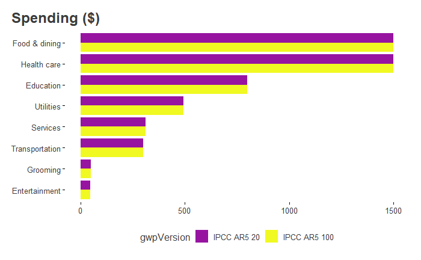

```r
# a chart object that is later going to be reactive
userCategorySpendingChartObject <-
  ggplot()+
  theme_539()+
  ggtitle("Spending ($)")+
  geom_bar(
    data=userCategoryChartData,
    aes(x=userCategory, y=actualSpending, fill=gwpVersion),
    position="dodge",
    stat="identity"
  )+
  coord_flip()+
  scale_fill_viridis(
    begin=0.32, end=1, discrete=T, direction=-1,
    option=sample(LETTERS[1:8],1),
    guide=guide_legend(reverse=T)
  )

userCategorySpendingChartObject
```

now let’s do the same thing for impacts. however i need to get the impact name from a reactive object

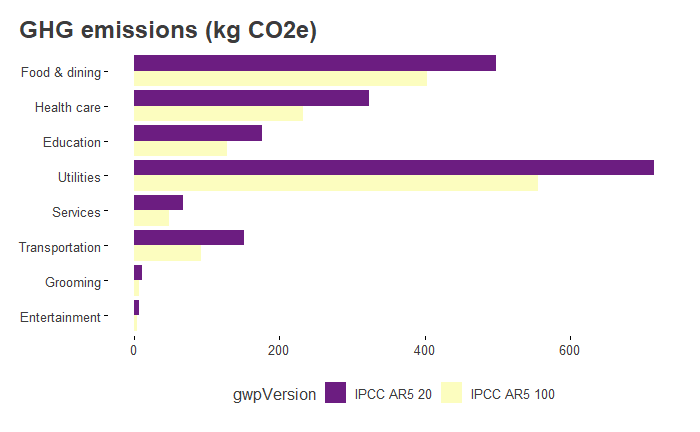

```r
# a chart object that is later going to be reactive
userCategoryImpactChartObject <-
  ggplot()+
  theme_539()+
  ggtitle(userCategoryImpactChartTitle)+
  geom_bar(
    data=userCategoryChartData,
    aes(x=userCategory, y=impact, fill=gwpVersion),
    position="dodge",
    stat="identity"
  )+
  coord_flip()+
  scale_fill_viridis(
    begin=0.32, end=1, discrete=T, direction=-1,
    option=sample(LETTERS[1:8],1),
    guide = guide_legend(reverse = T)
  )

userCategoryImpactChartObject
```

```r
# a data frame that's later going to be reactive
beaCategoryChartData <-
  impactsInDetail %>%
  filter(
    # later to be a selection in app...
    impactCategory=="GHG emissions",
    # later to be a multi checkbox selection in app...
    gwpVersion %in% c("IPCC AR5 100", "IPCC AR5 20")
  ) %>%
  group_by(impactCategory, impactUnits, gwpVersion, beaName) %>%
  summarise(
    impact=sum(impact),
    actualSpending=sum(actualSpending)
  ) %>%
  ungroup() %>%
  mutate(
    beaName=factor(beaName, levels=rev(beaCategoryNames)),
#    userCategory=factor(userCategory, levels=rev(userCategoryNames)),
    gwpVersion=factor(gwpVersion, levels=rev(gwpVersionNames))
  )
# a title for the impact category.. to be reactive
beaCategoryImpactChartTitle <-
  paste(
    beaCategoryChartData %>%
      select(impactCategory) %>%
      pull(impactCategory) %>%
      unique(),
    " (",
    beaCategoryChartData %>%
      select(impactUnits) %>%
      pull(impactUnits) %>%
      unique(),
    ")",
    sep=""
  )
```

now make a chart object and print it

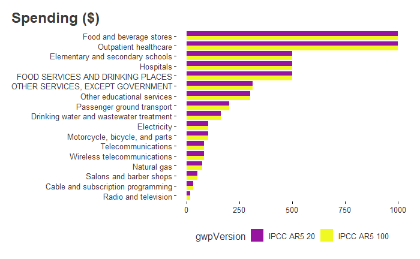

```r
# a chart object that is later going to be reactive
beaCategorySpendingChartObject <-
  ggplot()+
  theme_539()+
  ggtitle("Spending ($)")+
  geom_bar(
    data=beaCategoryChartData,
    aes(x=beaName, y=actualSpending, fill=gwpVersion),
    position="dodge",
    stat="identity"
  )+
  coord_flip()+
  scale_fill_viridis(
    begin=0.32, end=1, discrete=T, direction=-1,
    option=sample(LETTERS[1:8],1),
    guide=guide_legend(reverse=T)
  )

beaCategorySpendingChartObject
```

now let’s do the same thing for impacts. however i need to get the impact name from a reactive object

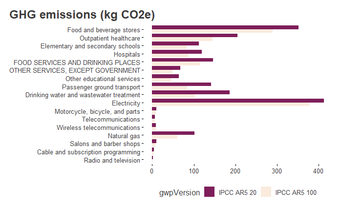

```r
# a chart object that is later going to be reactive
beaCategoryImpactChartObject <-
  ggplot()+
  theme_539()+
  ggtitle(beaCategoryImpactChartTitle)+
  geom_bar(
    data=beaCategoryChartData,
    aes(x=beaName, y=impact, fill=gwpVersion),
    position="dodge",
    stat="identity"
  )+
  coord_flip()+
  scale_fill_viridis(
    begin=0.32, end=1, discrete=T, direction=-1,
    option=sample(LETTERS[1:8],1),
    guide = guide_legend(reverse = T)
  )

beaCategoryImpactChartObject
```

### Progress

I’ve gotten an upload and download in the app. It’s basically working. Now I’ve got to

- make export functions (export chart data as excel, export charts themselves)
- do the anti join thing so that people can see which spending entries don’t match
- clean up the layout
- add a scatterchart of impact vs. spending (to find outliers)